## Overview

So the idea here is that we are going group NBA players into like group using a clustering algorithm The data is scraped from [Basketball Reference](https://www.basketball-reference.com/leagues/NBA_2023_per_game.html)

Lets take a look at our data.

```
## # A tibble: 6 × 30
##      rk player     pos     age tm        g    gs    mp    fg   fga fg_pe…¹   x3p
##   <dbl> <chr>      <chr> <dbl> <chr> <dbl> <dbl> <dbl> <dbl> <dbl>   <dbl> <dbl>
## 1     1 Precious … C        23 TOR      12     0   245    36    92   0.391     5
## 2     2 Steven Ad… C        29 MEM      16    16   419    51    80   0.638     0
## 3     3 Bam Adeba… C        25 MIA      15    15   517   111   210   0.529     0
## 4     4 Ochai Agb… SG       22 UTA       6     0    67     8    19   0.421     0
## 5     5 Santi Ald… PF       22 MEM      17    15   457    62   136   0.456    22
## 6     6 Nickeil A… SG       24 UTA       9     0    70     9    27   0.333     4
## # … with 18 more variables: x3pa <dbl>, x3p_percent <dbl>, x2p <dbl>,
## #   x2pa <dbl>, x2p_percent <dbl>, e_fg_percent <dbl>, ft <dbl>, fta <dbl>,
## #   ft_percent <dbl>, orb <dbl>, drb <dbl>, trb <dbl>, ast <dbl>, stl <dbl>,
## #   blk <dbl>, tov <dbl>, pf <dbl>, pts <dbl>, and abbreviated variable name
## #   ¹fg_percent
```

First we need to decide what columns to keep

| player | pos | age | g | gs | mp | fg | fga | x3p | x3pa | x2p | x2pa | ft | fta | orb | drb | ast | stl | blk | tov | pts |
| --- | --- | --- | --- | --- | --- | --- | --- | --- | --- | --- | --- | --- | --- | --- | --- | --- | --- | --- | --- | --- |
| Precious Achiuwa | C | 23 | 12 | 0 | 245 | 36 | 92 | 5 | 28 | 31 | 64 | 28 | 33 | 24 | 60 | 16 | 2 | 7 | 15 | 105 |
| Steven Adams | C | 29 | 16 | 16 | 419 | 51 | 80 | 0 | 0 | 51 | 80 | 10 | 43 | 77 | 93 | 38 | 13 | 16 | 39 | 112 |
| Bam Adebayo | C | 25 | 15 | 15 | 517 | 111 | 210 | 0 | 5 | 111 | 205 | 66 | 76 | 36 | 98 | 50 | 17 | 12 | 53 | 288 |
| Ochai Agbaji | SG | 22 | 6 | 0 | 67 | 8 | 19 | 0 | 6 | 8 | 13 | 4 | 7 | 4 | 6 | 1 | 0 | 0 | 0 | 20 |
| Santi Aldama | PF | 22 | 17 | 15 | 457 | 62 | 136 | 22 | 65 | 40 | 71 | 22 | 32 | 29 | 75 | 16 | 15 | 17 | 10 | 168 |
| Nickeil Alexander-Walker | SG | 24 | 9 | 0 | 70 | 9 | 27 | 4 | 13 | 5 | 14 | 4 | 5 | 0 | 6 | 10 | 5 | 3 | 5 | 26 |

Next we need to encode some of these categorical values.

Now let’s take a look at what the distribution of the stats look like overall

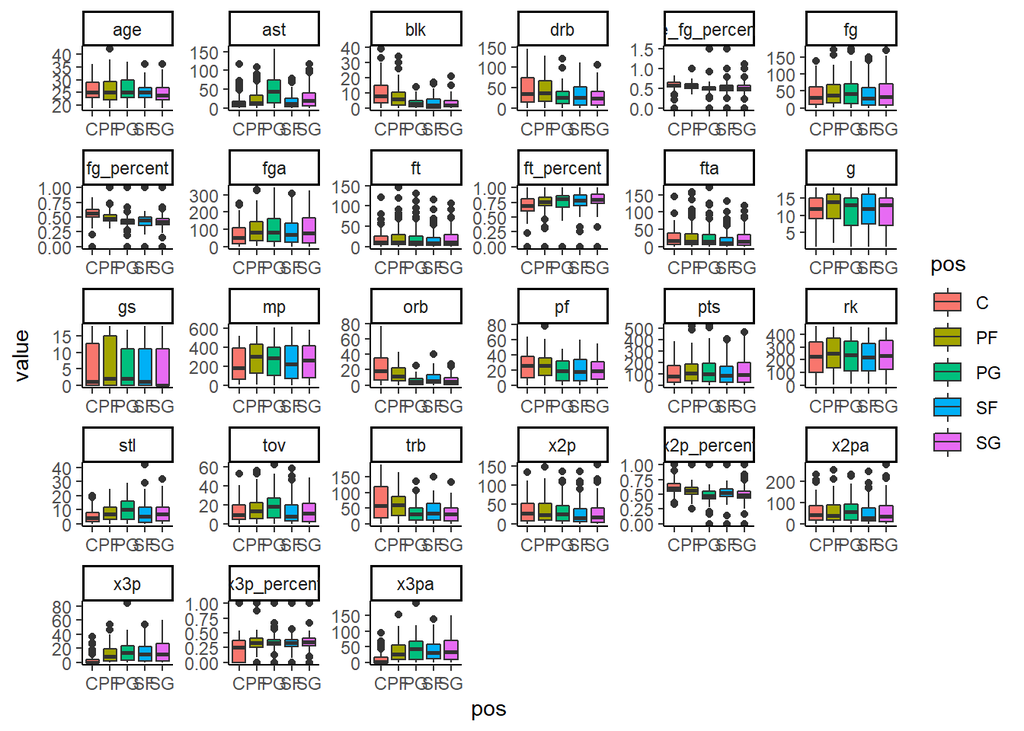

There are some outliers here for sure but lets roll with the data as is.

Before we model with 5 clusters (the same amount of positions on an NBA team) Lets look at the position counts as it stands today.

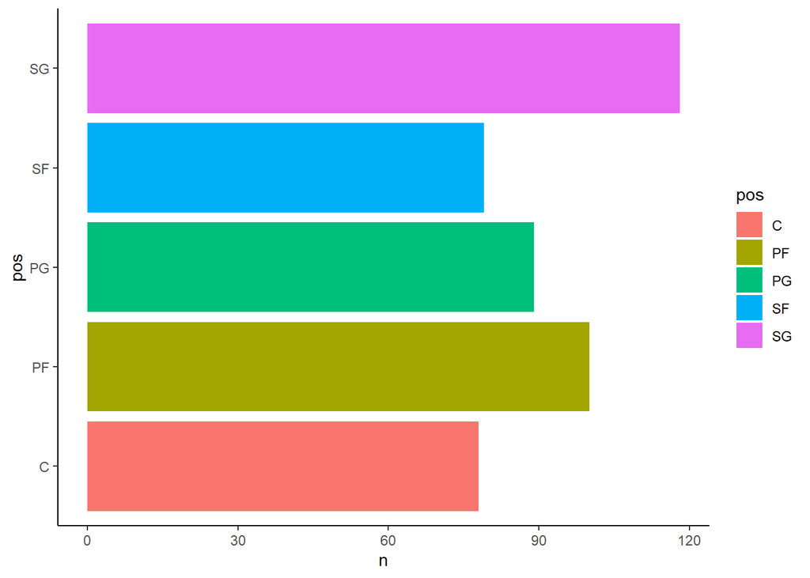

```
## # A tibble: 5 × 27
##     age     g     gs    mp     fg   fga   x3p  x3pa   x2p   x2pa    ft   fta
##   <dbl> <dbl>  <dbl> <dbl>  <dbl> <dbl> <dbl> <dbl> <dbl>  <dbl> <dbl> <dbl>
## 1  26.0 15.8  15.8   544.  129.   273.  34.4  96.1  94.9  177.   70.8  86.7
## 2  26.3 15.0   5.37  339.   48.0  104.  16.0  44.4  32.0   59.7  17.8  23.6
## 3  25.9 12.1   1.47  189.   25.3   54.6  8.21 23.6  17.1   31.0   9.88 13.1
## 4  24.6  5.30  0.214  44.0   5.48  13.0  1.53  5.28  3.94   7.67  2.21  3.19
## 5  26.6 14.9  12.5   451.   79.3  169.  23.1  63.1  56.2  106.   34.5  43.9
## # … with 15 more variables: orb <dbl>, drb <dbl>, ast <dbl>, stl <dbl>,
## #   blk <dbl>, tov <dbl>, pts <dbl>, pos_C <dbl>, pos_PF <dbl>, pos_PG <dbl>,
## #   pos_SF <dbl>, pos_SG <dbl>, size <int>, withinss <dbl>, cluster <fct>
```

Let’s take a look at the amount of players in each of the different clusters.

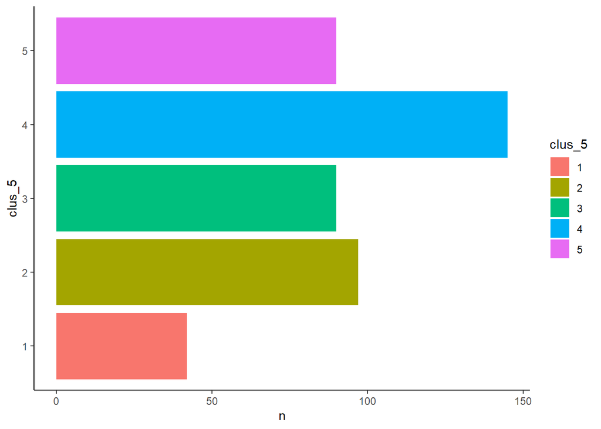

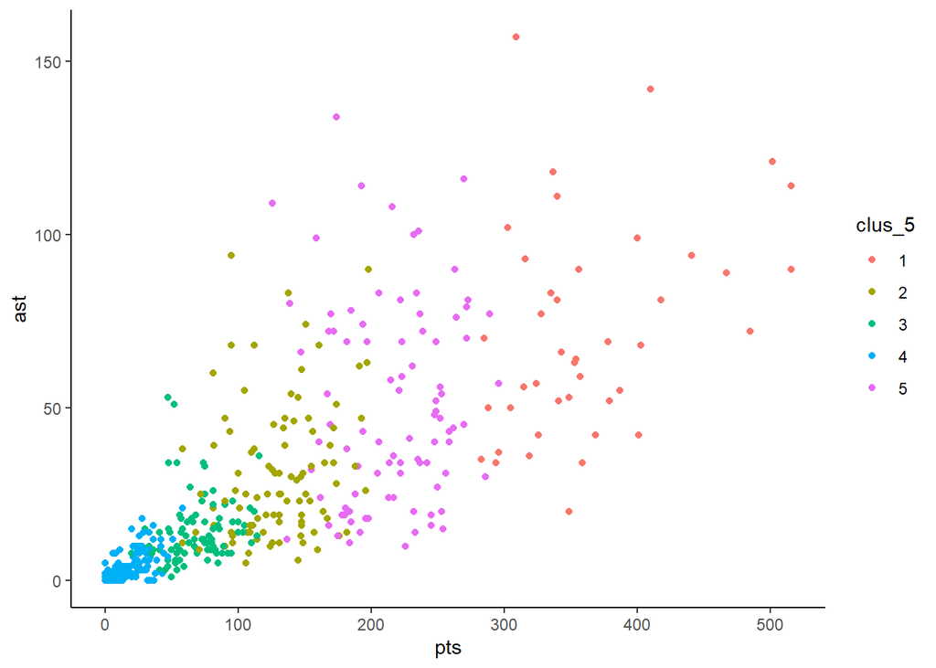

Now let’s take a looks at how each cluster stacks up against each other for every stat.

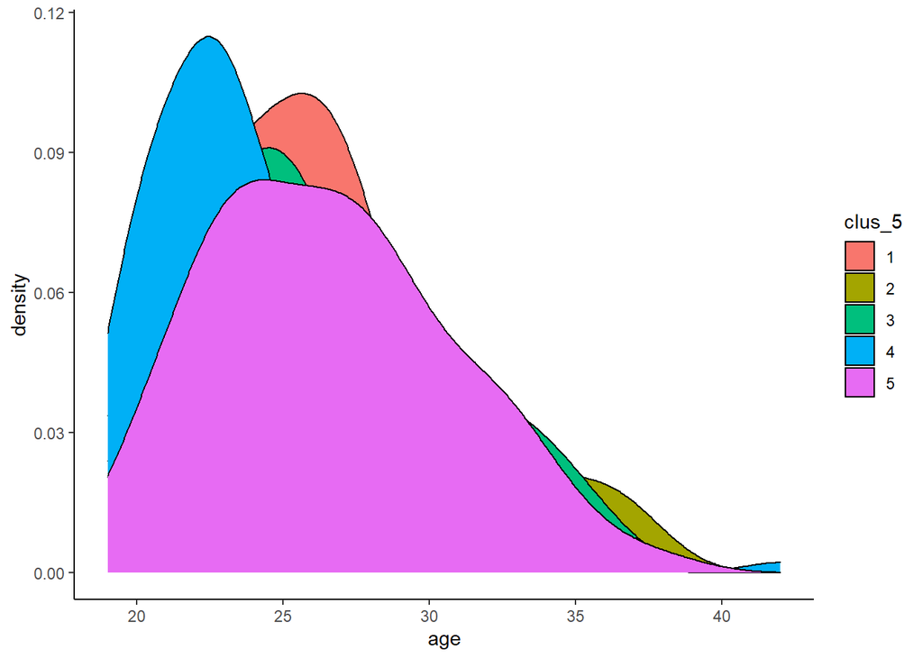

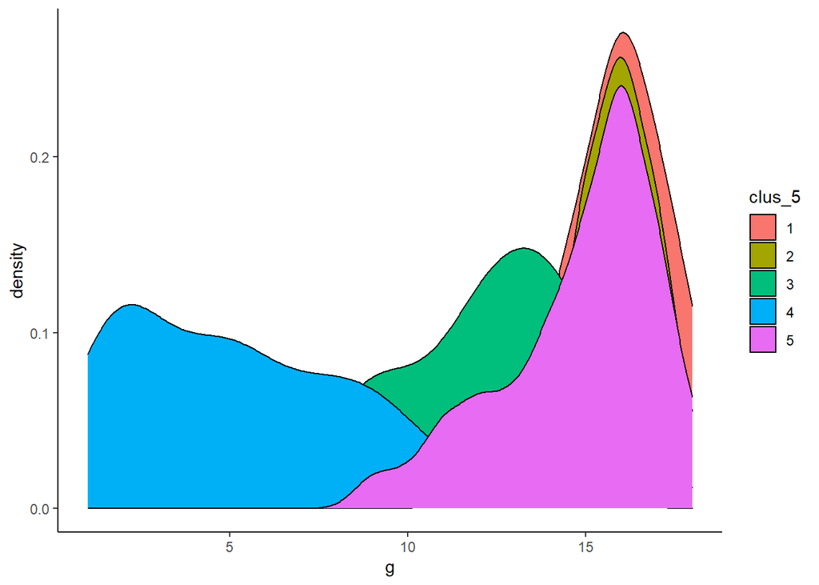

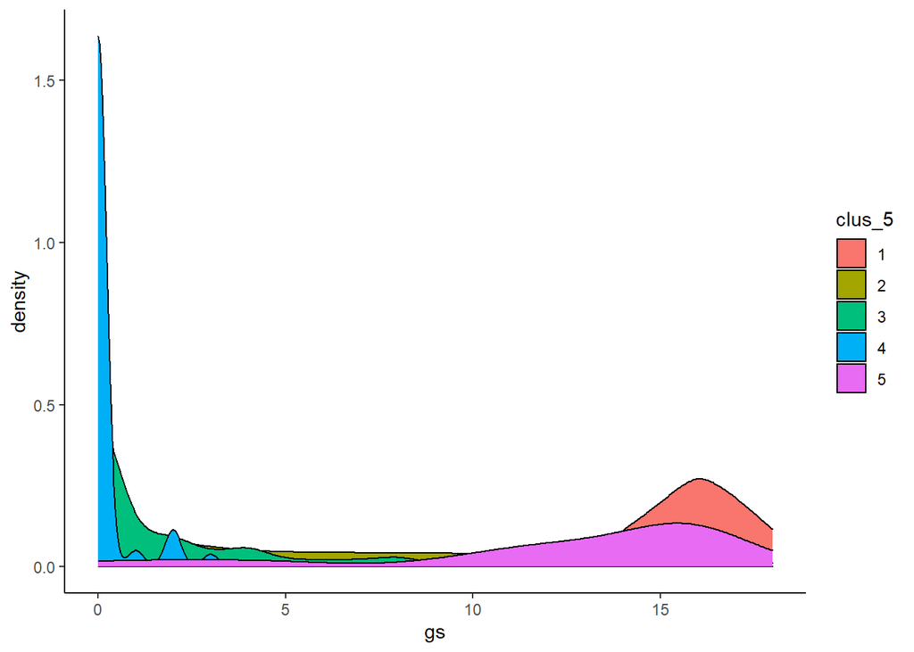

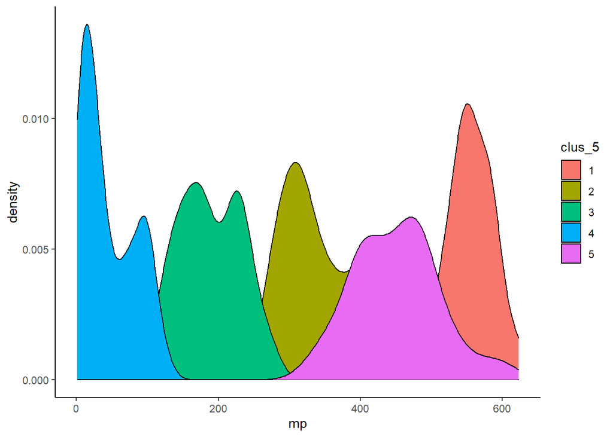

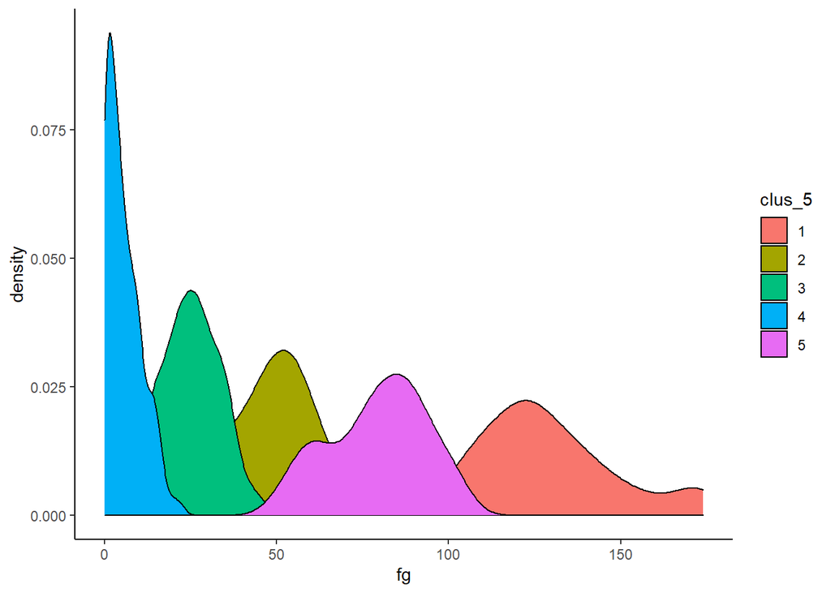

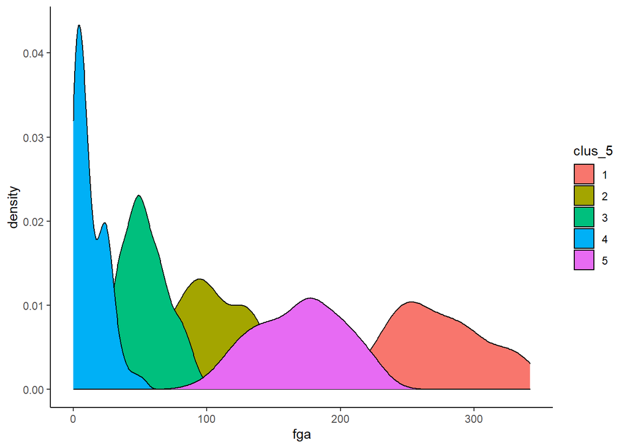

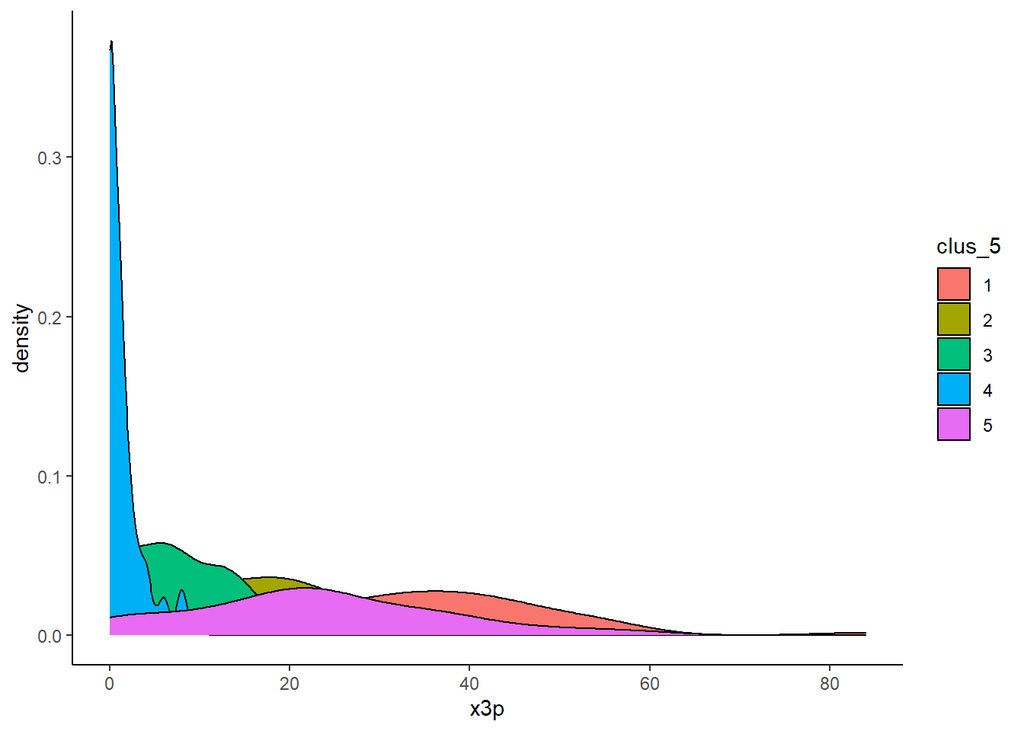

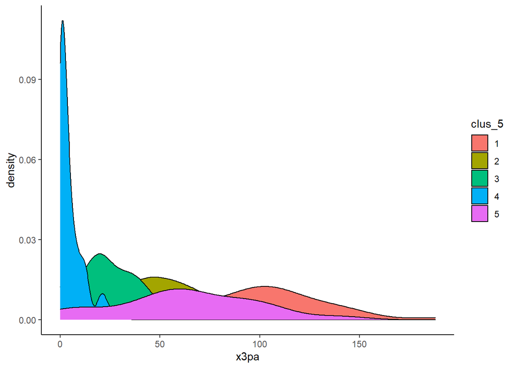

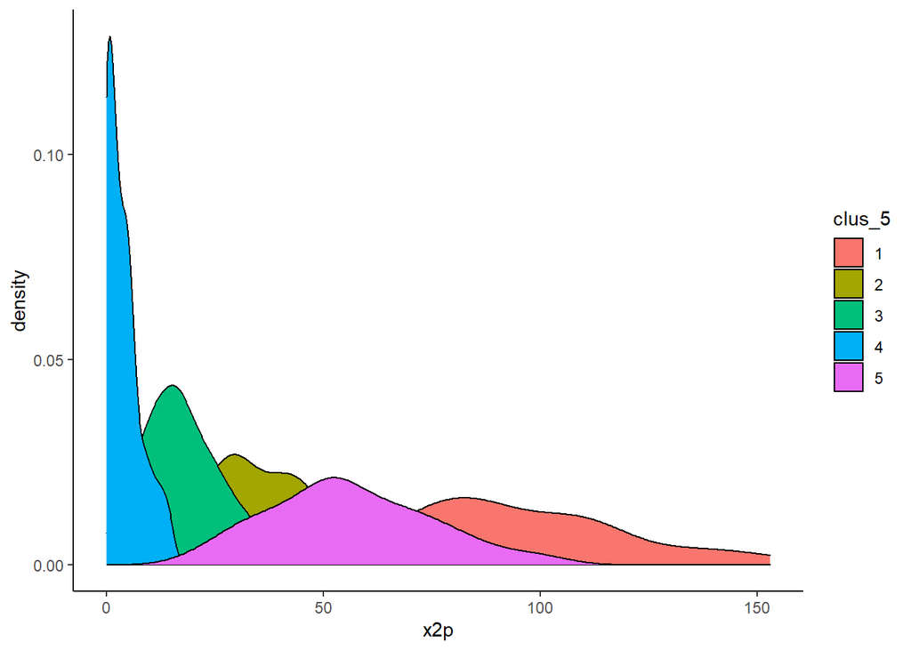

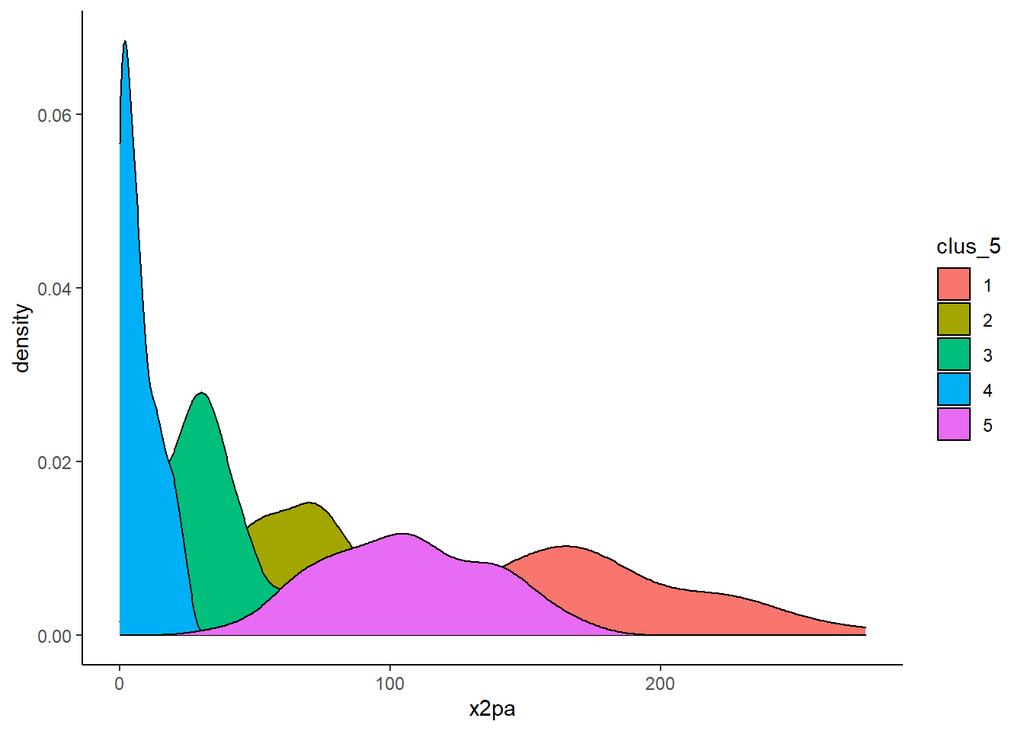

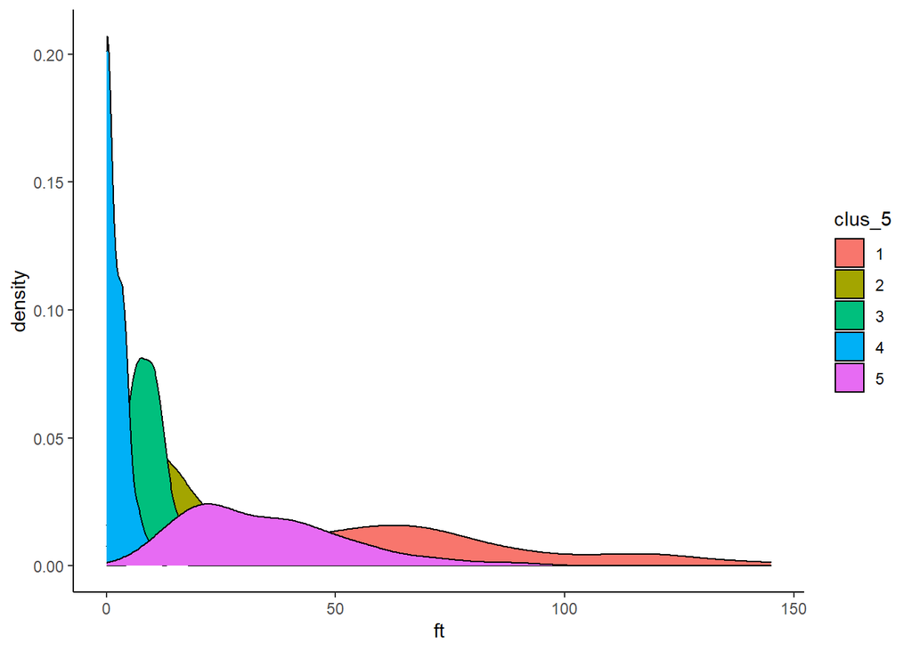

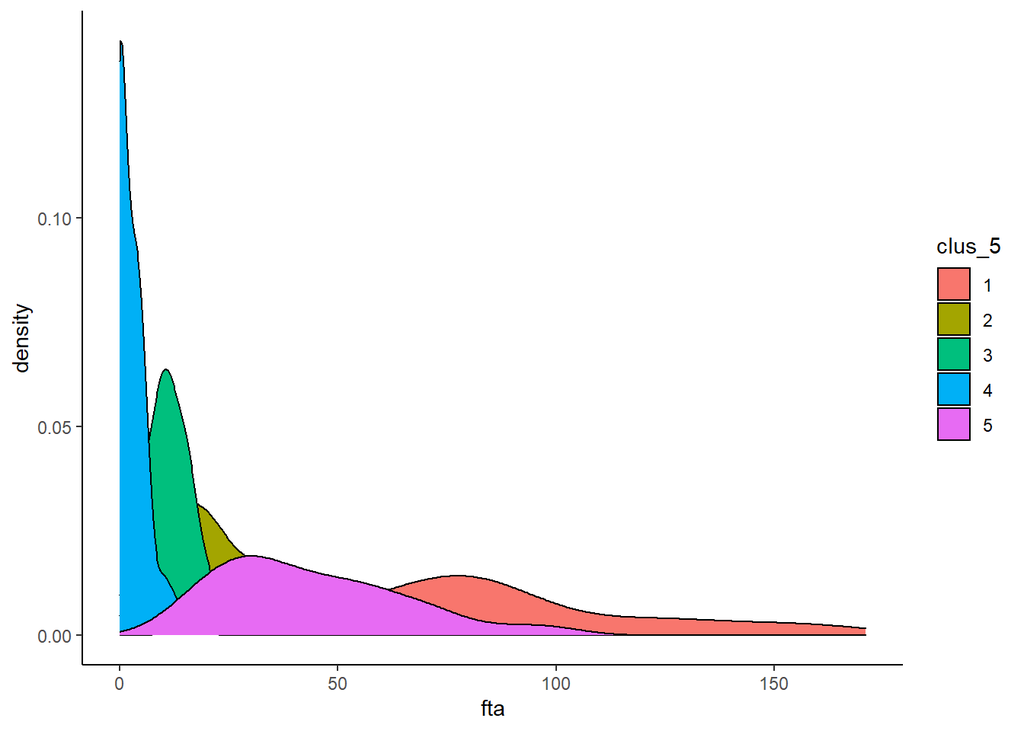

[7 more figures not shown]

```
## # A tibble: 464 × 26
##    player        age     g    gs    mp    fg   fga   x3p  x3pa   x2p  x2pa    ft
##    <fct>       <dbl> <dbl> <dbl> <dbl> <dbl> <dbl> <dbl> <dbl> <dbl> <dbl> <dbl>
##  1 Precious A…    23    12     0   245    36    92     5    28    31    64    28
##  2 Steven Ada…    29    16    16   419    51    80     0     0    51    80    10
##  3 Bam Adebayo    25    15    15   517   111   210     0     5   111   205    66
##  4 Ochai Agba…    22     6     0    67     8    19     0     6     8    13     4
##  5 Santi Alda…    22    17    15   457    62   136    22    65    40    71    22
##  6 Nickeil Al…    24     9     0    70     9    27     4    13     5    14     4
##  7 Grayson Al…    27    13    11   332    38    91    24    57    14    34    28
##  8 Jarrett Al…    24    14    14   462    81   141     0     2    81   139    34
##  9 Jose Alvar…    24    16     2   311    53   111    20    56    33    55     9
## 10 Kyle Ander…    29    12     2   235    27    52     6    14    21    38    15
## # … with 454 more rows, and 14 more variables: fta <dbl>, orb <dbl>, drb <dbl>,
## #   ast <dbl>, stl <dbl>, blk <dbl>, tov <dbl>, pts <dbl>, pos_C <int>,
## #   pos_PF <int>, pos_PG <int>, pos_SF <int>, pos_SG <int>, clus_5 <chr>
```

So it looks like our model has separated the players on skill. We’ll notice that the

- Red group (1) are the top players.
- Pink group (5) are the next best players
- Yellow group (2) are likely role players
- Green group (3) are the lower tier players
- Blue group (4) are likely young players and lower tier palyers.

Now that I’ve made the claim let me try and back it up.